# SimmsFishFence

Eric V

2024-11-17

# 1 Intro

Simms Creek is a small, 3rd order stream that drains an area of ~1,800 ha into the Salish Sea, near Campbell River’s Willow Point neighborhood. The lower reach of Simms Creek (~3 km of channel, east of Jubilee Road), is contained within a narrow urban green way that is bordered by residential properties. From Jubilee Road to the Inland Highway the stream is protected within [Beaver Lodge Lands](https://campbellriver.travel/news/forestry-guide-to-beaver-lodge-lands/), upstream of the Inland Highway, >1.5 km of tributary channel is located within private forest lands.

Historic fish observations indicate that Chum, Chinook, Pink and Coho Salmon have all been observed in the stream, as well as Coastal Cutthroat Trout, Rainbow Trout and Steelhead. Recent records, this dataset, suggest that Coho Salmon and Coastal Cutthroat Trout are the primary species within Simms Creek, both of which utilize the stream year round - though a small number of juvenile Chinook Salmon were identified in 2024.

[Greenways Land Trust](https://www.greenwaystrust.ca/) has supported Simms Creek Stewards for +20 years, including operation of a fish fence near the mouth of the stream since 2008. Juvenile and adult fish moving past the fence are tallied each spring and fall, respectively. The objective of this project is to explore the juvenile fence dataset. All work is being done strictly for fun and out of personal curiosity. Any feedback, input, or support is welcome. Also, I have a soft spot for Coastal Cutthroat Trout (CCT), so be warned that all analysis will be trout heavy.

# 2 Annual Fence Monitoring Effort and Catches

Annual trap operation periods and total captures of Coastal Cutthroat Trout and Coho Salmon are presented below in Table 1.

(#tab:display.table)**Table 1. Annual trap operation period, proportion of operation period that was monitored, proportion of migration period that was monitored (Apr 1 to June 15), and number of Coho Salmon and Coastal Cutthroat Trout that were tallied.**

| Year | Sample Period Start | Sample Period End | Sample Period # Days Sampled | Prop. Sampled (%) Sample Period | Prop. Sampled (%) Migration Period | # Fish Tallied CO | # Fish Tallied CCT | # Fish Tallied Total |
| --- | --- | --- | --- | --- | --- | --- | --- | --- |
| 2008 | Apr-21 | May-31 | 40 | 97.56% | 53.33% | 512 | 756 | 1268 |
| 2009 | Apr-20 | Jun-07 | 44 | 89.80% | 58.67% | 658 | 225 | 883 |
| 2010 | Apr-19 | May-30 | 41 | 97.62% | 54.67% | 477 | 502 | 979 |
| 2011 | Apr-20 | Jun-06 | 45 | 93.75% | 60.00% | 602 | 624 | 1226 |
| 2012 | Apr-16 | Jun-04 | 45 | 90.00% | 60.00% | 689 | 465 | 1154 |
| 2013 | Apr-15 | Jun-01 | 42 | 87.50% | 56.00% | 913 | 461 | 1374 |
| 2014 | Apr-26 | Jun-05 | 40 | 97.56% | 53.33% | 376 | 76 | 452 |
| 2015 | Apr-11 | May-31 | 47 | 92.16% | 62.67% | 761 | 141 | 902 |
| 2016 | Apr-05 | Jun-04 | 57 | 93.44% | 76.00% | 817 | 77 | 894 |
| 2017 | Apr-05 | Jun-11 | 64 | 94.12% | 85.33% | 335 | 65 | 400 |
| 2018 | Apr-21 | Jun-11 | 51 | 98.08% | 68.00% | 647 | 45 | 692 |
| 2019 | Apr-18 | Jun-05 | 44 | 89.80% | 58.67% | 405 | 571 | 976 |
| 2022 | Apr-28 | Jun-13 | 41 | 87.23% | 54.67% | 366 | 189 | 555 |
| 2024 | Apr-17 | Jun-04 | 49 | 100.00% | 65.33% | 644 | 701 | 1345 |

## 2.1 Coastal Cutthroat Trout

As previously mentioned, I like CCT, so let’s start there. We will look at the size of fish being captured, when the majority of the fish are migrating, and start to consider what may be driving some of the variability in migrants between years.

### 2.1.1 Size Distribution

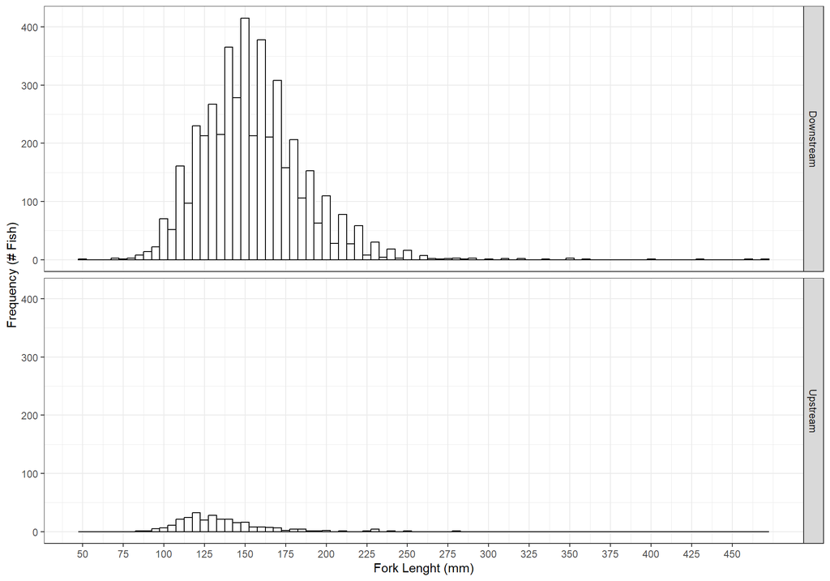

**Figure 1: Length-frequency of all Coastal Cutthroat Trout captured since 2008.**

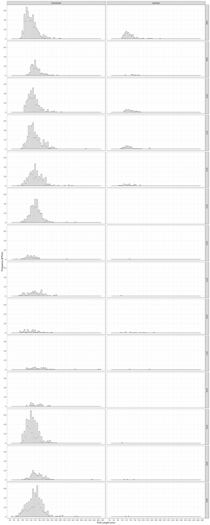

**Figure 2: Length-frequency of Coastal Cutthroat Trout captured during annual monitoring.**

### 2.1.2 Capture Timing

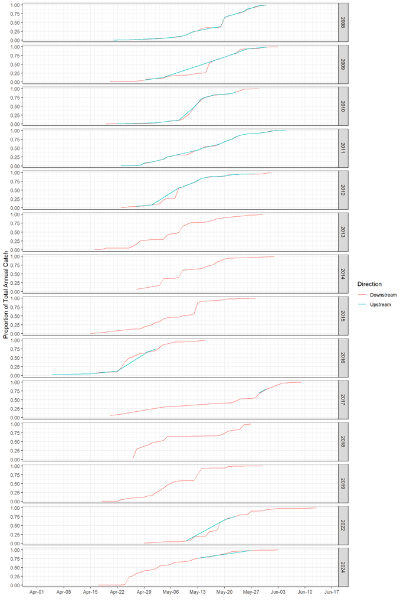

**Figure 3: Proportion of total annual upstream and downstream catches.**

[output not shown]

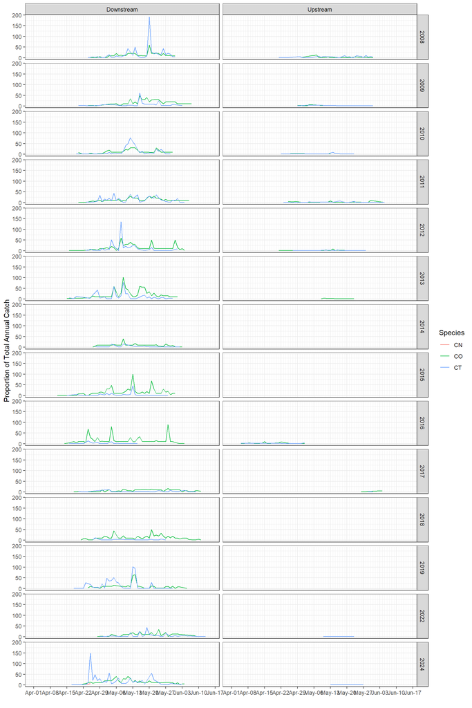

## 2.2 Coho Salmon